# Mini-Project

Amelia Aplikowski

```r
library(ggplot2)
library(dplyr)
library(rattle)
data(weatherAUS)
```

## Part 1: Introduction

I am using data that has weather information for all of Australia. However, I chose to focus on the weather in Sydney. There are 3984 days of weather data for Sydney. The data have features like temperature, humidity, and rainfall for each day. I wanted to examine two research questions.

Does rainfall increase when humidity increases? Does evaporation increase when maximum temperature increases? I also examined this question with additional predictors.

## Part 2: Analysis

```r
sydney <- weatherAUS %>%
  filter(Location == "Sydney")
```

My first question examines if rainfall increases when humidity increases. I thought that, because humidity is a measure of water in the air, that it might affect the amount of precipitation that occurs. Because I am looking at if humidity caused higher rainfall, I decided to only look at days where it did rain. This way I can examine if higher humidity did cause higher rainfall.

```r
sydney_rain <- sydney %>%
  filter(Rainfall > 0)
```

I started by creating a visualization of rainfall and humidity. I can see that there does seem to be a positive trend. However, there are many data points with low rainfall at all percentages of humidity.

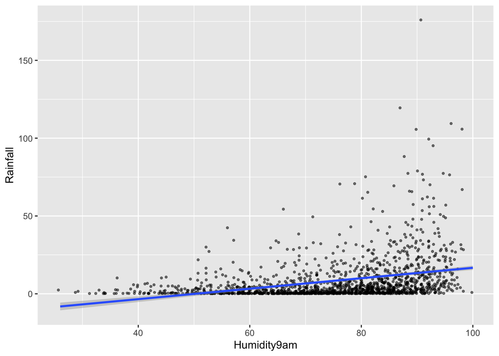

```r
ggplot(sydney_rain, aes(y = Rainfall, x = Humidity9am)) +
  geom_jitter(alpha = 0.5, size = 0.75, na.rm = TRUE) +
  geom_smooth(method = "lm", se = TRUE, na.rm = TRUE)
```

Next, I created a model of rainfall as a response variable and humidity as a predictor. From the coefficient of Humidity9am, I can see that, on average, rainfall increases 0.3358858 mm for each 1% increase in humidity.

```r
rainfall_model_1 <- lm(Rainfall ~ Humidity9am, sydney_rain)
summary(rainfall_model_1)$coef
```

```
##                Estimate Std. Error   t value     Pr(>|t|)
## (Intercept) -16.8792738   1.899480 -8.886261 1.769683e-18
## Humidity9am   0.3358858   0.024921 13.478020 3.631488e-39
```

```r
3.631488e-39/2
```

```
## [1] 1.815744e-39
```

The p-value is 3.631488e-39. This means that the probability that we would observe this sample if there were no relationship is 3.631488e-39.

Overall, there is a statistically significant relationship between rainfall and humidity. However, it is not very meaningful because it only accounts for a small increase in rainfall, especially compared to the broad range of rainfall amounts that were observed in the data.

I am 95% confident that for every 1% increase in humidity, the rainfall in Sydney, Australia increased by between 0.2870021 mm and 0.3847695 mm. This is a small confidence interval even though the small number means that it is not very meaningful.

```r
confint(rainfall_model_1, level = 0.95)
```

```
##                   2.5 %      97.5 %
## (Intercept) -20.6051923 -13.1533553
## Humidity9am   0.2870021   0.3847695
```

Overall, humidity accounts for 10.8% of the variation in rainfall.

```r
summary(rainfall_model_1)$r.squared
```

```
## [1] 0.1080226
```

I created a logistic regression model for whether it rained today based on the humidity in order to see if increased humidity increases the likelihood of rain for a specific day.

```r
rainfall_model_2 <- glm(RainToday ~ Humidity9am, family = "binomial", sydney)
summary(rainfall_model_2)$coef
```

```
##              Estimate  Std. Error   z value      Pr(>|z|)
## (Intercept) -6.988810 0.264893024 -26.38352 2.118168e-153
## Humidity9am  0.082247 0.003508195  23.44425 1.512934e-121
```

This model reveals that for every 1% increase in humidity the odds of it raining increase by 8.57%.

```r
exp(0.082247)
```

```
## [1] 1.085724
```

For my second question, I wanted to explore some predictors for evaporation. Because water evaporates differently at different temperatures, I thought that the temperature of the day might affect evaporation.

I started by creating a visualization of evaporation and the maximum temperature of the day. From the plot, I can see that there is a positive correlation between evaporation and max temp.

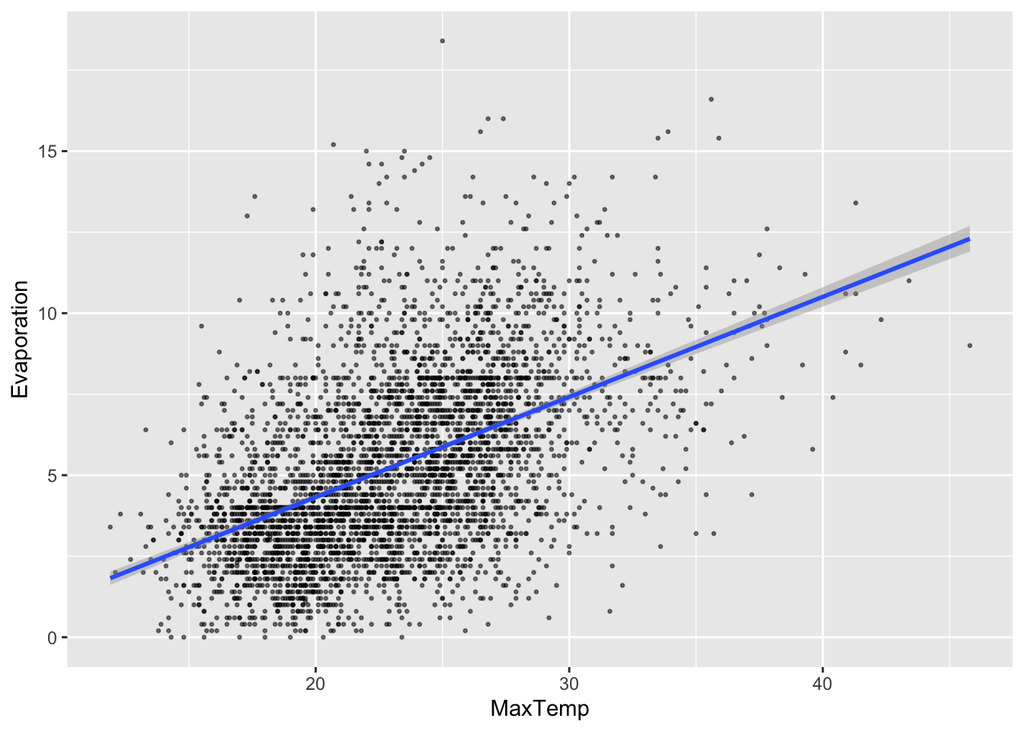

```r
ggplot(sydney, aes(y = Evaporation, x = MaxTemp)) +
  geom_point(alpha = .5, size = .5, na.rm = TRUE) +
  geom_smooth(method = "lm", se = TRUE, na.rm = TRUE)
```

Next, I created a model of evaporation and max temp. The coefficient for MaxTemp tells me that, on average, for each degree of increase in maximum temperature, there was a 0.3089543 mm increase in evaporation.

```r
evaporation_model_1 <- lm(Evaporation ~ MaxTemp, sydney)
summary(evaporation_model_1)$coef
```

```
##               Estimate  Std. Error   t value      Pr(>|t|)
## (Intercept) -1.8538271 0.204830953 -9.050522  2.194060e-19
## MaxTemp      0.3089543 0.008705878 35.488009 2.085416e-239
```

```r
2.085416e-239 / 2
```

```
## [1] 1.042708e-239
```

The p-value is 2.085416e-239. This means that the probability that we would observe this sample if there were no relationship between max temp and evaporation is 2.085416e-239.

There is a statistically significant association between evaporation and max temp. It is also meaningful because the amount of evaporation is significant in terms of evaporation.

I am 95% confident that for every 1 degree increase in max temp, the increase in evaporation in Sydney, Australia is between 0.2918858 mm and 0.3260228 mm.

```r
confint(evaporation_model_1, level = 0.95)
```

```
##                  2.5 %     97.5 %
## (Intercept) -2.2554126 -1.4522416
## MaxTemp      0.2918858  0.3260228
```

Overall, max temp accounts for 24.3% of the variation in evaporation

```r
summary(evaporation_model_1)$r.squared
```

```
## [1] 0.2434845
```

Next, I wanted to see if there were other predictors that could explain more about evaporation. I added humidity to the plot. In general it seems that with higher humidity, there is lower evaporation, and with lower humidity there is higher evaporation.

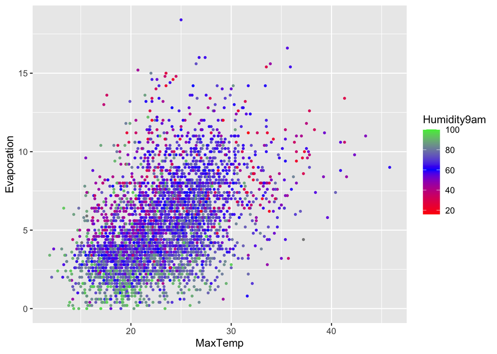

```r
ggplot(sydney, aes(y = Evaporation, x = MaxTemp, color = Humidity9am)) +
  geom_point(alpha = .9, size = .75, na.rm = TRUE) +
  scale_color_gradient2(low = "red", high = "green", mid = "blue", midpoint = 60)
```

Next, I created a model for evaporation, max temp, wind speed, and humidity. The MaxTemp coefficient tells me that when controlling for wind speed and humidity, on average evaporation increased 0.282585764 mm for each 1 degree increase in max temp. The negative coefficient on Humidity9am tells me that, on average, evaporation does decrease as humidity increases, when controlling for max temp and wind speed.

When looking at the test statistic and p-value for MaxTemp, it is clear that MaxTemp is still statistically significant. The p-value for Humidity is way less than 0.05 and, therefore, is statistically significant. However, WindSpeed9am does not appear to be statistically significant (p-value: 9.729187e-02 > 0.05).

```r
evaporation_model_2 <- lm(Evaporation ~ MaxTemp +  WindSpeed9am + Humidity9am, sydney)
summary(evaporation_model_2)$coef
```

```
##                  Estimate  Std. Error    t value      Pr(>|t|)
## (Intercept)   2.498214978 0.354362815   7.049879  2.114252e-12
## MaxTemp       0.282585764 0.009108596  31.024076 9.738397e-189
## WindSpeed9am  0.009606825 0.005792365   1.658532  9.729187e-02
## Humidity9am  -0.057943492 0.002575190 -22.500666 2.067131e-105
```

```r
1.803457294 + 0.264727607 * 23 - 0.001749587 * 10 - 0.062992366 * 70
```

```
## [1] 3.465231
```

I am 95% confident that the evaporation for this specific day is between 0.5573903 mm and 9.518032 mm. This is a pretty wide range for evaporation.

```r
predict(evaporation_model_2, newdata = data.frame(MaxTemp = 23, WindSpeed9am = 10, Humidity9am = 70),
      interval = "prediction", level = 0.95)
```

```
##        fit       lwr      upr
## 1 5.037711 0.5573903 9.518032
```

However, I am 95% confident that that the average evaporation for days with these characteristics is between 4.946437 mm and 5.128986 mm.

```r
predict(evaporation_model_2, newdata = data.frame(MaxTemp = 23, WindSpeed9am = 10, Humidity9am = 70),
      interval = "confidence", level = 0.95)
```

```
##        fit      lwr      upr
## 1 5.037711 4.946437 5.128986
```

All together, the maximum temperature, wind speed, and humidity explain 34.3% of the variation in evaporation. This is larger than the r-squared from evaporation_model_1, so wind speed and humidity did account for some variation in evaporation.

```r
summary(evaporation_model_2)$r.squared
```

```
## [1] 0.3432916
```

## Part 3: Collaboration

My group was pretty successful at collaboration. In our larger breakout room, we talked about the data which was helpful. Even though we worked on different models, we were able to help each other problem solve. If I were to improve something for next time, I would be a little more involved in my group members projects and reaching out. I think we could have communicated a bit more. I was consistently engaged when we met. Ari Holcombe Pomerance consistently engaged with me. Quinn Frankovsky was also consistently engaged when we worked together in a breakout room one day.